# Impact of Severe Weather Events on Public Health and Economy in the U.S.

Bertrand

2026-01-16

## Synopsis

Severe weather events can cause substantial harm to communities, including injuries and fatalities as well as extensive property and crop damage.  
This report analyzes the U.S. National Oceanic and Atmospheric Administration (NOAA) Storm Data database (1950–November 2011) to identify which event types have the greatest public health impacts and which have the greatest economic consequences.  
Public health impact is assessed using the total number of fatalities and injuries, aggregated by event type.  
Economic impact is assessed using total property and crop damages, converted to U.S. dollars based on the recorded magnitude exponents (e.g., K, M, B).  
To improve comparability, event types are standardized by trimming whitespace and converting to uppercase.  
Results are presented as top-10 summaries and two bar plots to support prioritization of preparedness resources.  
Overall, the analysis highlights a small number of event categories that dominate health impacts and a partly different set of categories that dominate economic losses.  
The code and transformations are fully documented so that the analysis is reproducible from the raw compressed CSV file. —

## Data Processing

```r
knitr::opts_chunk$set(echo = TRUE, warning = FALSE, message = FALSE)

# Load packages (install if missing)
if (!requireNamespace("dplyr", quietly = TRUE)) install.packages("dplyr")
if (!requireNamespace("ggplot2", quietly = TRUE)) install.packages("ggplot2")
if (!requireNamespace("scales", quietly = TRUE)) install.packages("scales")

library(dplyr)
library(ggplot2)
library(scales)
file <- "repdata_data_StormData.csv.bz2"

# Read compressed CSV directly

storm <- read.csv(file, stringsAsFactors = FALSE)

dim(storm)
```

```
## [1] 902297     37
```

```r
names(storm)[1:15]
```

```
##  [1] "STATE__"    "BGN_DATE"   "BGN_TIME"   "TIME_ZONE"  "COUNTY"
##  [6] "COUNTYNAME" "STATE"      "EVTYPE"     "BGN_RANGE"  "BGN_AZI"
## [11] "BGN_LOCATI" "END_DATE"   "END_TIME"   "COUNTY_END" "COUNTYENDN"
```

```r
data <- storm %>%
select(EVTYPE, FATALITIES, INJURIES, PROPDMG, PROPDMGEXP, CROPDMG, CROPDMGEXP) %>%
mutate(
EVTYPE = toupper(trimws(EVTYPE))
)

summary(data$FATALITIES)
```

```
##     Min.  1st Qu.   Median     Mean  3rd Qu.     Max.
##   0.0000   0.0000   0.0000   0.0168   0.0000 583.0000
```

```r
summary(data$INJURIES)
```

```
##      Min.   1st Qu.    Median      Mean   3rd Qu.      Max.
##    0.0000    0.0000    0.0000    0.1557    0.0000 1700.0000
```

```r
exp_map <- function(x) {
x <- toupper(trimws(x))
dplyr::case_when(
x == "H" ~ 1e2,
x == "K" ~ 1e3,
x == "M" ~ 1e6,
x == "B" ~ 1e9,
x == ""  ~ 1,
x == "0" ~ 1,
x == "1" ~ 10,
x == "2" ~ 1e2,
x == "3" ~ 1e3,
x == "4" ~ 1e4,
x == "5" ~ 1e5,
x == "6" ~ 1e6,
x == "7" ~ 1e7,
x == "8" ~ 1e8,
x == "9" ~ 1e9,
TRUE ~ NA_real_
)
}

data <- data %>%
mutate(
prop_mult = exp_map(PROPDMGEXP),
crop_mult = exp_map(CROPDMGEXP),
prop_damage = PROPDMG * prop_mult,
crop_damage = CROPDMG * crop_mult,
econ_damage = prop_damage + crop_damage
)

# Quick check of missing multipliers (unexpected exponent codes)

sum(is.na(data$prop_mult))
```

```
## [1] 14
```

```r
sum(is.na(data$crop_mult))
```

```
## [1] 7
```

```r
health <- data %>%
group_by(EVTYPE) %>%
summarise(
fatalities = sum(FATALITIES, na.rm = TRUE),
injuries   = sum(INJURIES, na.rm = TRUE),
total_health = fatalities + injuries,
.groups = "drop"
) %>%
arrange(desc(total_health))

top_health <- health %>% slice_head(n = 10)

top_health
```

```
## # A tibble: 10 × 4
##    EVTYPE            fatalities injuries total_health
##    <chr>                  <dbl>    <dbl>        <dbl>
##  1 TORNADO                 5633    91346        96979
##  2 EXCESSIVE HEAT          1903     6525         8428
##  3 TSTM WIND                504     6957         7461
##  4 FLOOD                    470     6789         7259
##  5 LIGHTNING                816     5230         6046
##  6 HEAT                     937     2100         3037
##  7 FLASH FLOOD              978     1777         2755
##  8 ICE STORM                 89     1975         2064
##  9 THUNDERSTORM WIND        133     1488         1621
## 10 WINTER STORM             206     1321         1527
```

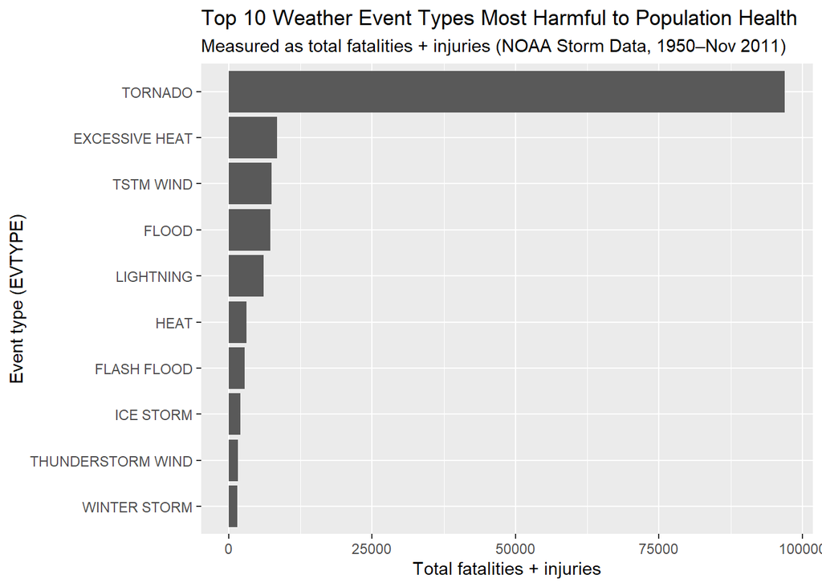

```r
# Figure 1: Top 10 event types by total health impact

ggplot(top_health, aes(x = reorder(EVTYPE, total_health), y = total_health)) +
geom_col() +
coord_flip() +
labs(
title = "Top 10 Weather Event Types Most Harmful to Population Health",
subtitle = "Measured as total fatalities + injuries (NOAA Storm Data, 1950–Nov 2011)",
x = "Event type (EVTYPE)",
y = "Total fatalities + injuries"
)
```

```r
econ <- data %>%
group_by(EVTYPE) %>%
summarise(
property_damage = sum(prop_damage, na.rm = TRUE),
crop_damage     = sum(crop_damage, na.rm = TRUE),
total_econ      = sum(econ_damage, na.rm = TRUE),
.groups = "drop"
) %>%
arrange(desc(total_econ))

top_econ <- econ %>% slice_head(n = 10)

top_econ
```

```
## # A tibble: 10 × 4
##    EVTYPE            property_damage crop_damage    total_econ
##    <chr>                       <dbl>       <dbl>         <dbl>
##  1 FLOOD               144657709807   5661968450 150319678257
##  2 HURRICANE/TYPHOON    69305840000   2607872800  71913712800
##  3 TORNADO              56947380616.   414953270  57362333886.
##  4 STORM SURGE          43323536000         5000  43323541000
##  5 HAIL                 15735267513.  3025954473  18761221986.
##  6 FLASH FLOOD          16822723978.  1421317100  18244041078.
##  7 DROUGHT               1046106000  13972566000  15018672000
##  8 HURRICANE            11868319010   2741910000  14610229010
##  9 RIVER FLOOD           5118945500   5029459000  10148404500
## 10 ICE STORM             3944927860   5022113500   8967041360
```

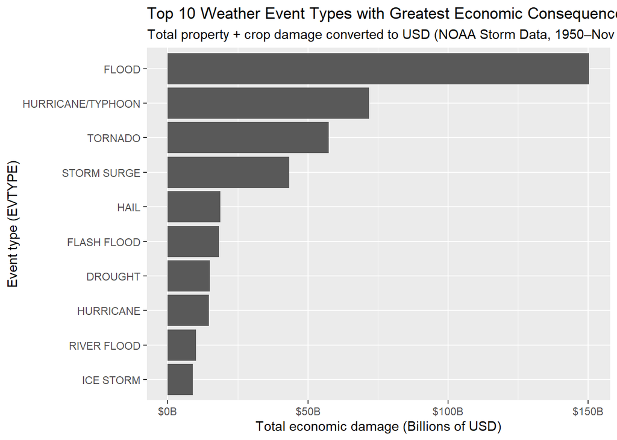

```r
# Figure 2: Top 10 event types by total economic damage

ggplot(top_econ, aes(x = reorder(EVTYPE, total_econ), y = total_econ)) +
geom_col() +
coord_flip() +
scale_y_continuous(labels = label_dollar(scale = 1e-9, suffix = "B")) +
labs(
title = "Top 10 Weather Event Types with Greatest Economic Consequences",
subtitle = "Total property + crop damage converted to USD (NOAA Storm Data, 1950–Nov 2011)",
x = "Event type (EVTYPE)",
y = "Total economic damage (Billions of USD)"
)
```

```r
# Top 3 (health)
h3 <- top_health %>% slice_head(n = 3)

# Top 3 (economic)
e3 <- top_econ %>% slice_head(n = 3)

# Helper formatters
fmt_int <- function(x) format(round(x), big.mark = ",")
fmt_usd <- function(x) paste0("$", format(round(x), big.mark = ","))

# Build decision-maker oriented text (English)
health_paragraph <- paste0(
  "Public health impacts are dominated by ",
  h3$EVTYPE[1], ", followed by ", h3$EVTYPE[2], " and ", h3$EVTYPE[3], ". ",
  "Across 1950–Nov 2011, ", h3$EVTYPE[1], " accounts for ",
  fmt_int(h3$fatalities[1]), " fatalities and ", fmt_int(h3$injuries[1]),
  " injuries (total ", fmt_int(h3$total_health[1]), "). ",
  "The next two event types, ", h3$EVTYPE[2], " and ", h3$EVTYPE[3],
  ", account for totals of ", fmt_int(h3$total_health[2]), " and ",
  fmt_int(h3$total_health[3]), " affected people (fatalities + injuries), respectively."
)

econ_paragraph <- paste0(
  "Economic losses are dominated by ",
  e3$EVTYPE[1], ", followed by ", e3$EVTYPE[2], " and ", e3$EVTYPE[3], ". ",
  "Total damage (property + crops) is estimated at ",
  fmt_usd(e3$total_econ[1]), " for ", e3$EVTYPE[1], " (property: ",
  fmt_usd(e3$property_damage[1]), "; crops: ", fmt_usd(e3$crop_damage[1]), "). ",
  "The next two event types, ", e3$EVTYPE[2], " and ", e3$EVTYPE[3],
  ", are associated with ", fmt_usd(e3$total_econ[2]), " and ",
  fmt_usd(e3$total_econ[3]), " in total losses, respectively."
)

priority_sentence <- paste0(
  "Prioritization should consider that the leading event types for human harm and for economic loss are not always identical; ",
  "preparedness planning should therefore balance life-safety measures with investments that reduce high-cost damages."
)

health_paragraph
```

[output not shown]

```r
econ_paragraph
```

[output not shown]

```r
priority_sentence
```

```
## [1] "Prioritization should consider that the leading event types for human harm and for economic loss are not always identical; preparedness planning should therefore balance life-safety measures with investments that reduce high-cost damages."
```